# Exploring the NOAA Storm Database : Health and Economic impacts of Severe Weather in the US.

### Assignment

The basic goal of this assignment is to explore the NOAA Storm Database and answer some basic questions about severe weather events. You must use the database to answer the questions below and show the code for your entire analysis. Your analysis can consist of tables, figures, or other summaries. You may use any R package you want to support your analysis.

### Synopsis

Storms and other severe weather events can cause both public health and economic problems for communities and municipalities.

This project involves exploring the U.S. National Oceanic and Atmospheric Administration’s (NOAA) storm database. This database tracks characteristics of major storms and weather events in the United States, including when and where they occur, as well as estimates of any fatalities, injuries, and property damage.

### The data analysis must address the following questions :

Across the United States, which types of events (as indicated in the EVTYPE variable) are most harmful with respect to population health ? Across the United States, which types of events have the greatest economic consequences ?

### This analysis shows by aggregating the data by storm events type :

- Tornados are the most harmfull events on population health (including injury and fatalities).
- Floods are responsible for the most economic damage.

## Data Processing

```r
library(data.table)
library(R.utils)
library(ggplot2)
library(dplyr)
```

```r
# Checking if file exists and if not then downloading
if(!file.exists("stormData.csv.bz2")) {
  download.file("https://d396qusza40orc.cloudfront.net/repdata%2Fdata%2FStormData.csv.bz2",
  destfile = "stormData.csv.bz2", method = "curl")
}

# using fread to create dataframe
raw_data <- fread("stormData.csv.bz2", sep = ",", header = TRUE)
```

```r
#Sebsetting NOAA database to required fields
df_noaa <-  raw_data[,c('EVTYPE','FATALITIES','INJURIES', 'PROPDMG', 'PROPDMGEXP', 'CROPDMG', 'CROPDMGEXP')]
```

Convert H, K, M, B units to calculate Property Damage as per discussion in forums [here!](https://www.coursera.org/learn/reproducible-research/discussions/weeks/4/threads/38y35MMiEeiERhLphT2-QA)

```r
df_noaa$PROPDMGNUM = 0
df_noaa[df_noaa$PROPDMGEXP == "H", ]$PROPDMGNUM = df_noaa[df_noaa$PROPDMGEXP == "H", ]$PROPDMG * 10^2
df_noaa[df_noaa$PROPDMGEXP == "K", ]$PROPDMGNUM = df_noaa[df_noaa$PROPDMGEXP == "K", ]$PROPDMG * 10^3
df_noaa[df_noaa$PROPDMGEXP == "M", ]$PROPDMGNUM = df_noaa[df_noaa$PROPDMGEXP == "M", ]$PROPDMG * 10^6
df_noaa[df_noaa$PROPDMGEXP == "B", ]$PROPDMGNUM = df_noaa[df_noaa$PROPDMGEXP == "B", ]$PROPDMG * 10^9
```

Convert H, K, M, B units to calculate Crop Damage as per the discussion in forums [here!](https://www.coursera.org/learn/reproducible-research/discussions/weeks/4/threads/38y35MMiEeiERhLphT2-QA)

```r
df_noaa$CROPDMGNUM = 0
df_noaa[df_noaa$CROPDMGEXP == "H", ]$CROPDMGNUM = df_noaa[df_noaa$CROPDMGEXP == "H", ]$CROPDMG * 10^2
df_noaa[df_noaa$CROPDMGEXP == "K", ]$CROPDMGNUM = df_noaa[df_noaa$CROPDMGEXP == "K", ]$CROPDMG * 10^3
df_noaa[df_noaa$CROPDMGEXP == "M", ]$CROPDMGNUM = df_noaa[df_noaa$CROPDMGEXP == "M", ]$CROPDMG * 10^6
df_noaa[df_noaa$CROPDMGEXP == "B", ]$CROPDMGNUM = df_noaa[df_noaa$CROPDMGEXP == "B", ]$CROPDMG * 10^9
```

## Results

### Question 1 : Across the United States, which types of events (as indicated in the EVTYPE variable) are most harmful with respect to population health?

I am going to consider both Injuries and Fatalities as Harmful hence we will calculate the sum of both columns

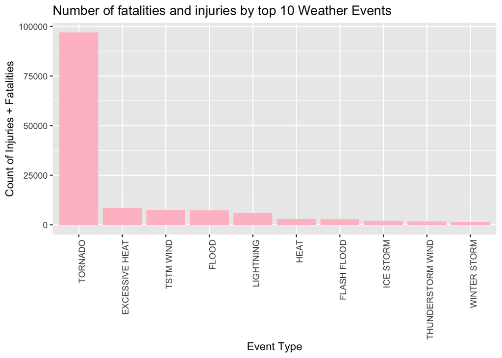

```r
# harmful events aggregation summing fatalities + injuries
harmful_events <- aggregate(FATALITIES+INJURIES ~ EVTYPE, data = df_noaa, sum)

#ordering the dataset for top 10 events
harmful_events_top10 <- harmful_events[order(-harmful_events$FATALITIES),][1:10,]
harmful_events_top10 <- harmful_events_top10 %>%
     rename(FI = `FATALITIES + INJURIES`)
harmful_events_top10$EVTYPE <- factor(harmful_events_top10$EVTYPE, levels = harmful_events_top10$EVTYPE)




#Creating the plot to see the top 10

ggplot(data = harmful_events_top10, aes(x= EVTYPE, y= FI)) +
     geom_bar(fill = "pink", stat="identity") +
     theme(axis.text.x = element_text(angle = 90, hjust = 1)) +
     labs(x="Event Type", y= "Count of Injuries + Fatalities", title = "Number of fatalities and injuries by top 10 Weather Events")
```

### Answer to Question 1

```r
print(paste("As we can see among the top 10 Event Types the maximum fatalities and injuries are caused by", harmful_events_top10$EVTYPE[ which.max(harmful_events_top10$FI)]))
```

```
## [1] "As we can see among the top 10 Event Types the maximum fatalities and injuries are caused by TORNADO"
```

### Question 2 : Across the United States, which types of events have the greatest economic consequences?

Economic consequences are considerd as both Property and Crop Damages. We will use the PROPDMGNUM and CROPDMGNUM columns which we converted earlier to numbers using their exponents.

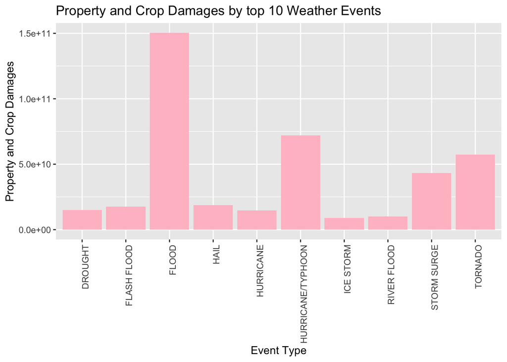

```r
eco_damage <- aggregate(PROPDMGNUM+CROPDMGNUM ~ EVTYPE, data =  df_noaa, sum)
eco_damage <- eco_damage %>% rename(damage = `PROPDMGNUM + CROPDMGNUM` )

eco_damage_top10 <- eco_damage[order(-eco_damage$damage), ][1:10, ]



ggplot(data = eco_damage_top10, aes(x= EVTYPE, y= damage)) +
     geom_bar(fill = "pink", stat="identity") +
     theme(axis.text.x = element_text(angle = 90, hjust = 1)) +
     labs(x="Event Type", y= "Property and Crop Damages", title = "Property and Crop Damages by top 10 Weather Events")
```

### Answer to Question 2

```r
print(paste("As we can see among the top 10 Event Types the maximum fatalities and injuries are caused by", eco_damage_top10$EVTYPE[ which.max(eco_damage_top10$damage)]))
```

[output not shown]